# EDAV Problem Set 1 Fall 2025

Author

Mayur Suhas Kulkarni (msk2277)

### IMPORTANT NOTES FOR ALL QUESTIONS

See “Assignment Guidelines” under Pages in CourseWorks for instructions that apply to all assignments. (The guidelines will grow as the semester progresses so check back for each new assignment.)

Read *Graphical Data Analysis with R*, Ch. 3, 4, 5

### 1. Nutrition

[8 points]

Data: “food.csv” file in /data folder in CourseWorks

1. Draw multiple horizontal boxplots of `calories`, by `restaurant`. What do you observe?

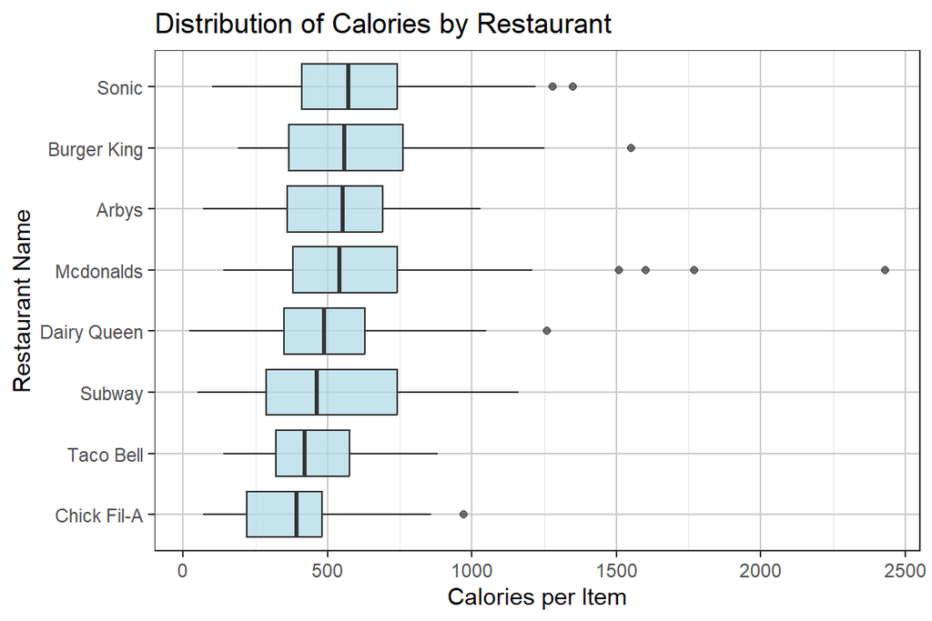

```r
#Loading the required libraries in R
library(ggplot2)
library(dplyr)
library(readr)
library(stringr)

#loading the data file
food_data <- read_csv("food.csv")
# Horizontal boxplots
ggplot(food_data, aes(x = calories, y = reorder(restaurant, calories, median))) +
  geom_boxplot(fill = "lightblue", alpha = 0.7) +
  labs(
    title = "Distribution of Calories by Restaurant",
    x = "Calories per Item",
    y = "Restaurant Name"
  ) +
  theme_bw() +
  theme(
    panel.grid.major = element_line(color = "grey80"),
    panel.grid.minor = element_line(color = "grey90")
  )
```

Observations:

1. Chick Fil-A has the lowest median calorie count.
2. Subway shows a wider inter quartile range in calories compared to others.
3. Mc Donalds has the most number of calorie outliers in their menu. Max calorie item is present in McD. Contorary to this, Dairy Queen has the minimum calorie item in the dataset.
2. Draw histograms, faceted by `restaurant`, for the same data. Describe one insight that was not visible in the boxplots.

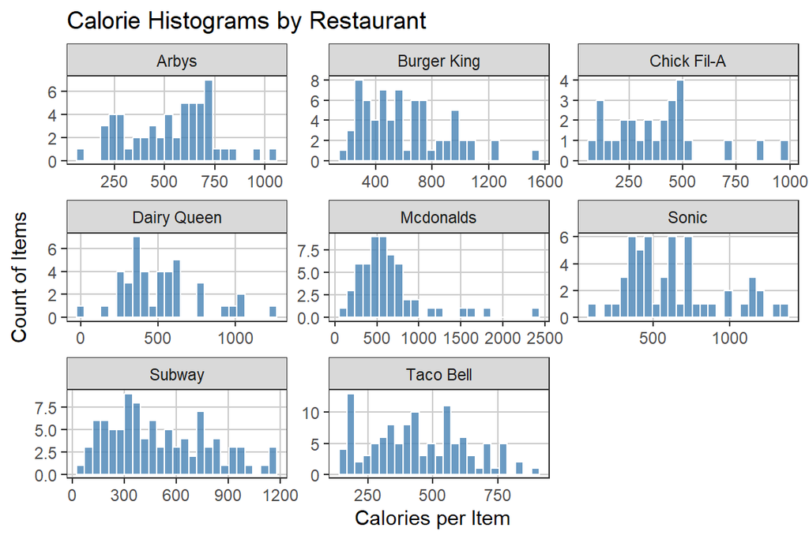

```r
# Name: Mayur Suhas Kulkarni
# Date: Sept 2025

#Loading the required libraries in R

library(ggplot2)
library(dplyr)
library(readr)
library(stringr)

#loading the data file
food_data <- read_csv("food.csv")
ggplot(food_data, aes(x = calories)) +
  geom_histogram(bins = 25, fill = "steelblue", color = "white", alpha = 0.8) +
  facet_wrap(~restaurant, scales = "free") +
  labs(
    title = "Calorie Histograms by Restaurant",
    x = "Calories per Item",
    y = "Count of Items"
  ) +
  theme_bw() +
  theme(
    panel.grid.major = element_line(color = "grey80"),
    panel.grid.minor = element_blank()
  )
```

3. Do crispy items have more calories than grilled items? Use overlapping density curves to compare.

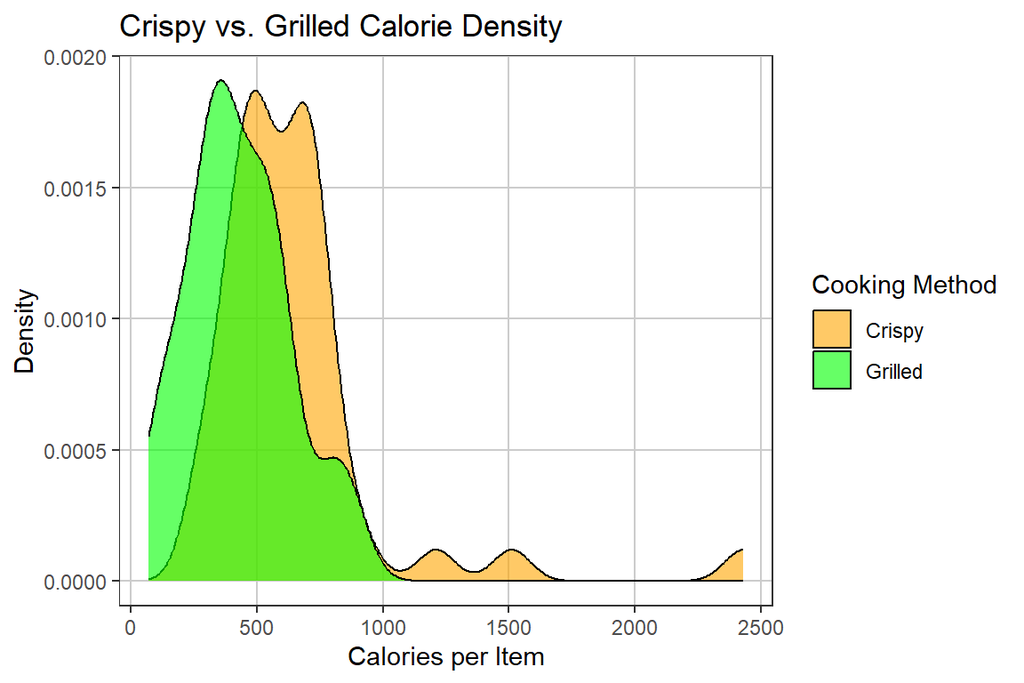

```r
# Name: Mayur Suhas Kulkarni
# Date: Sept 2025

#Loading the required libraries in R

library(ggplot2)
library(dplyr)
library(readr)
library(stringr)

#loading the data file
food_data <- read_csv("food.csv")
cooking_cmp <- food_data |>
  filter(str_detect(tolower(item), "crispy|grilled")) |>
  mutate(
    method = case_when(
      str_detect(tolower(item), "crispy") ~ "Crispy",
      str_detect(tolower(item), "grilled") ~ "Grilled",
      TRUE ~ NA_character_
    )
  ) |>
  filter(!is.na(method))

ggplot(cooking_cmp, aes(x = calories, fill = method)) +
  geom_density(alpha = 0.6) +
  scale_fill_manual(values = c("Crispy" = "orange", "Grilled" = "green")) +
  labs(
    title = "Crispy vs. Grilled Calorie Density",
    x = "Calories per Item",
    y = "Density",
    fill = "Cooking Method"
  ) +
  theme_bw() +
  theme(
    panel.grid.major = element_line(color = "grey80"),
    panel.grid.minor = element_blank()
  )
```

Therefore, the crispy items have a relative number of higher calories than the grilled ones.

4. Expand on part c) by creating a single ridgeline plot that show the distributions of grilled vs crispy for each restaurant. What do you observe?

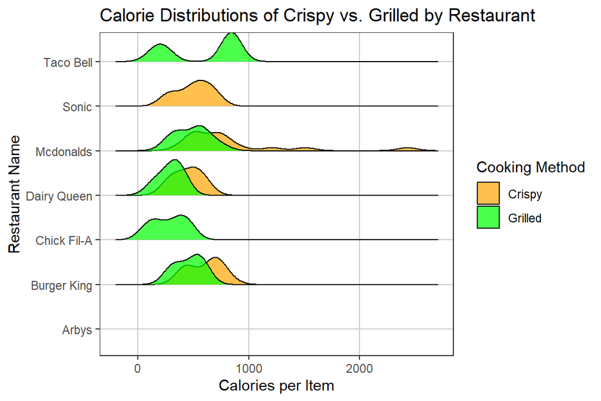

```r
# Name: Mayur Suhas Kulkarni
# Date: Sept 2025

#Loading the required libraries in R

library(ggplot2)
library(dplyr)
library(readr)
library(stringr)
library(ggridges)


#loading the data file
food_data <- read_csv("food.csv")
ggplot(cooking_cmp, aes(x = calories, y = restaurant, fill = method)) +
  geom_density_ridges(alpha = 0.7, scale = 0.8) +
  scale_fill_manual(values = c("Crispy" = "orange", "Grilled" = "green")) +
  labs(
    title = "Calorie Distributions of Crispy vs. Grilled by Restaurant",
    x = "Calories per Item",
    y = "Restaurant Name",
    fill = "Cooking Method"
  ) +
  theme_bw() +
  theme(
    panel.grid.major = element_line(color = "grey80"),
    panel.grid.minor = element_blank()
  )
```

Sonic and Chick-fil-A appear to specialize in one cooking method over the other . Sonic primarily features crispy items in this comparison, while Chick-fil-A only shows a grilled distribution. Arby’s does not have any items matching either crispy or grilled in the dataset.

### 2. Temporal Lobes

[8 points]

Data: *mtl* in **openintro** package

1. Draw two histograms–one with base R and the other with **ggplot2**–of the variable representing the thickness of the subiculum subregion of the medial temporal lobe using the default parameters. What is the default method each uses to determine the number of bins? (For base R, show the calculation for this data.) Which do you think is a better choice for this dataset and why?
2. Draw two histograms of the `age` variable with boundaries at multiples of 5, one right closed and one right open. Every boundary should be labeled (45, 50, 55, etc.)
3. Add the same parameter value(s) to the code of your plots from part b) so that the result is that the right open and right closed versions are identical. Explain your strategy.

### 3. Soybeans

[8 points]

Data: *australia.soybean* in **agridat** package

1. Use QQ (quantile-quantile) plots with theoretical normal lines to compare `yield` for the four locations. For which location does the `yield` appear to be closest to a normal distribution?

```r
library(agridat)
library(ggplot2)
library(gridExtra)
# Load data from the dataset
data("australia.soybean")

## Get locations from the dataset
locations <- unique(australia.soybean$loc)
print(locations)
```

```
[1] Lawes      Brookstead Nambour    RedlandBay
Levels: Brookstead Lawes Nambour RedlandBay
```

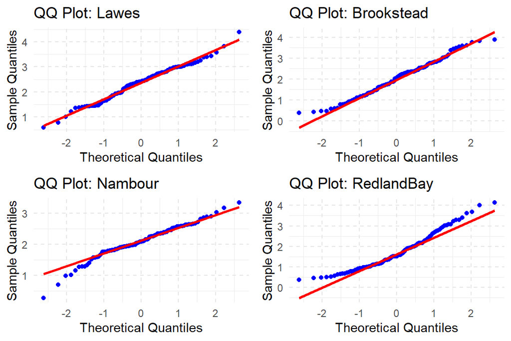

```r
# Here, I am creating QQ plots for each location
qq_plots <- list()

for(i in 1:length(locations)) {
  loc_data <- subset(australia.soybean, loc == locations[i])

  qq_plots[[i]] <- ggplot(loc_data, aes(sample = yield)) +
    stat_qq(color = "blue") +
    stat_qq_line(color = "red", linewidth = 1) +
    labs(title = paste("QQ Plot:", locations[i]),
         x = "Theoretical Quantiles",
         y = "Sample Quantiles") +
    theme_minimal() +
    theme(panel.grid.major = element_line(color = "gray90", linetype = "dashed"))
}

# Display all plots locationwise
grid.arrange(grobs = qq_plots, ncol = 2, nrow = 2)
```

2. Draw density histograms with density curves and theoretical normal curves overlaid of `yield` for the four locations.

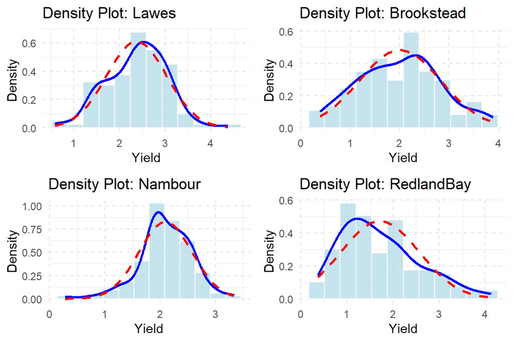

```r
library(agridat)
library(ggplot2)
library(gridExtra)

data("australia.soybean")
locations <- unique(australia.soybean$loc)

# Creating density plots at each location
density_plots <- list()

for(i in 1:length(locations)) {
  loc_data <- subset(australia.soybean, loc == locations[i])

  # Calculating the mean and standard deviation
  mean_y <- mean(loc_data$yield)
  sd_y <- sd(loc_data$yield)

  density_plots[[i]] <- ggplot(loc_data, aes(x = yield)) +
    # Histogram with density which is drawn
    geom_histogram(aes(y = after_stat(density)), bins = 12,
                   fill = "lightblue", color = "white", alpha = 0.7) +
    # Actual density curve to be drawn
    geom_density(color = "blue", size = 1) +
    # Theoretical normal curve to be drawn
    stat_function(fun = dnorm,
                  args = list(mean = mean_y, sd = sd_y),
                  color = "red", size = 1, linetype = "dashed") +
    labs(title = paste("Density Plot:", locations[i]),
         x = "Yield", y = "Density") +
    theme_minimal() +
    theme(panel.grid.major = element_line(color = "gray90", linetype = "dashed"))
}
grid.arrange(grobs = density_plots, ncol = 2, nrow = 2)
```

Here Blue line is the actual data density and the Red dashed line represents theoretical normal density

3. Perform Shapiro-Wilk tests for normality for `yield` for each location using the `shapiro.test()` function and interpret the results.

```r
library(agridat)
data("australia.soybean")

locations <- unique(australia.soybean$loc)

for (loc in locations) {
  y <- australia.soybean$yield[australia.soybean$loc == loc]
  test <- shapiro.test(y)
  cat("Location:", loc, "\n")
  cat("  W =", round(test$statistic, 4),
      "  p-value =", round(test$p.value, 4), "\n")
  if (test$p.value > 0.05) {
    cat("  Interpretation: yield appears NORMAL (fail to reject H₀)\n")
  } else {
    cat("  Interpretation: yield appears NON-NORMAL (reject H₀)\n")
  }
}
```

```
Location: Lawes
  W = 0.9869   p-value = 0.3279
  Interpretation: yield appears NORMAL (fail to reject H₀)
Location: Brookstead
  W = 0.9857   p-value = 0.2594
  Interpretation: yield appears NORMAL (fail to reject H₀)
Location: Nambour
  W = 0.973   p-value = 0.0191
  Interpretation: yield appears NON-NORMAL (reject H₀)
Location: RedlandBay
  W = 0.9523   p-value = 4e-04
  Interpretation: yield appears NON-NORMAL (reject H₀)
```

Here, data at Lawes and Brookstead do not show significant deviation from normality. Other two locations deviate.

4. Did all of the methods for testing for normality (a, b, and c) produce the same results? Briefly explain.

When the three methods for testing normality were analyzed, there was agreement seen in 3 out of the 4 locations.

In Lawes:

QQ plot points lie almost exactly on the red line and density curves had observed and theoretical curves ones match closely

p = 0.3279 (>0.05) → fail to reject normality from Shapiro Wilk

Nambour

QQ plot had noticeable tail deviations and density curve method had blue curve skewed relative to red dashed curve.

Also, p = 0.0191 (≤0.05) → reject normality from Shapiro Wilk

RedlandBay

QQ plot had clear curvature away from the line in the upper tail and there was substantial mismatch between observed and normal curves in the density plot.

p = 0.0004 (≤0.05) → reject normality as per Shapiro Wilk

Brookstead shows a minor disagreement between the visual and statistical estimates:

Therefore, Visual methods are subjective and can suggest deviations in statistically insginificant regions as well. Evaluation through Shapiro Wilk test would be a better method.

### 4. Doctors

[4 points]

Data: *breslow* dataset in **boot** package

Draw histograms of the age at death for deaths attributed to coronary artery disease among doctors in the *breslow* dataset, faceted on smoking status.

### 5. Loans

[5 points]

Data: *loans_full_schema* in **openintro** package

1. Use an appropriate graphical technique to describe the distribution of the `loan_amount` variable. What do you observe?

```r
#checking out the dataset once

library(openintro)
library(dplyr)
library(ggplot2)

data(loans_full_schema)

#exploring the data here and check the schema
glimpse(loans_full_schema)
```

```
Rows: 10,000
Columns: 55
$ emp_title                        <chr> "global config engineer ", "warehouse…
$ emp_length                       <dbl> 3, 10, 3, 1, 10, NA, 10, 10, 10, 3, 1…
$ state                            <fct> NJ, HI, WI, PA, CA, KY, MI, AZ, NV, I…
$ homeownership                    <fct> MORTGAGE, RENT, RENT, RENT, RENT, OWN…
$ annual_income                    <dbl> 90000, 40000, 40000, 30000, 35000, 34…
$ verified_income                  <fct> Verified, Not Verified, Source Verifi…
$ debt_to_income                   <dbl> 18.01, 5.04, 21.15, 10.16, 57.96, 6.4…
$ annual_income_joint              <dbl> NA, NA, NA, NA, 57000, NA, 155000, NA…
$ verification_income_joint        <fct> , , , , Verified, , Not Verified, , ,…
$ debt_to_income_joint             <dbl> NA, NA, NA, NA, 37.66, NA, 13.12, NA,…
$ delinq_2y                        <int> 0, 0, 0, 0, 0, 1, 0, 1, 1, 0, 0, 0, 0…
$ months_since_last_delinq         <int> 38, NA, 28, NA, NA, 3, NA, 19, 18, NA…
$ earliest_credit_line             <dbl> 2001, 1996, 2006, 2007, 2008, 1990, 2…
```

[output cut: 42 more lines]

```r
#checking skewness and number of unique loan purposes in the data
skewness_calc <- function(x) {
  n <- length(x)
  mean_x <- mean(x)
  sd_x <- sd(x)
  skew <- sum((x - mean_x)^3) / (n * sd_x^3)
  return(skew)
}

cat("Skewness:", round(skewness_calc(loans_full_schema$loan_amount), 3), "\n")
```

```
Skewness: 0.704
```

```r
cat("Number of unique loan purposes:", length(unique(loans_full_schema$loan_purpose)), "\n")
```

```
Number of unique loan purposes: 12
```

```r
#checking loan purposes and their frequencies

table(loans_full_schema$loan_purpose)
```

```
                                  car        credit_card debt_consolidation
                 0                131               2249               5144
  home_improvement              house     major_purchase            medical
               680                151                303                162
            moving              other   renewable_energy     small_business
                69                914                 10                125
          vacation            wedding
                62                  0
```

```r
#checking for quartile, their inter quartile range and finding outlier points ( at 1.5*(IQR) from Q1 and Q3)

Q1 <- quantile(loans_full_schema$loan_amount, 0.25)
Q3 <- quantile(loans_full_schema$loan_amount, 0.75)
IQR <- Q3 - Q1
cat("number of IQR outliers:", sum(loans_full_schema$loan_amount < Q1 - 1.5*IQR |
                        loans_full_schema$loan_amount > Q3 + 1.5*IQR), "\n")
```

```
number of IQR outliers: 0
```

Few observations from the dataset:

1. Loan amount is a continuous variable and has a large range.
2. The data shows moderate positive skewness (0.704). Therefore the right tail is extended and lower amounts have more concentration, which can be incorporated in a histogram.
3. There are no extreme outliers as per IQR method.

This suggests Histogram as a good representation of this data as it reveals modality and gaps in data.

Also, bar chart is eliminated as loan amount is continuous variable. Density plot is a good choice, but not as intutive as an histogram for this purpose. Box plot misses out clustering patterns, but reveals median and quartiles without the distrubution shape.

Histogram code:

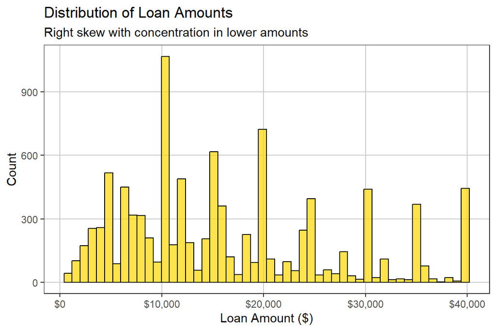

```r
# Histogram with appropriate bin selection
ggplot(loans_full_schema, aes(x = loan_amount)) +
  geom_histogram(bins = 50, fill = "gold", color = "black", alpha = 0.7) +
  labs(
    title = "Distribution of Loan Amounts",
    subtitle = "Right skew with concentration in lower amounts",
    x = "Loan Amount ($)",
    y = "Count"
  ) +
  scale_x_continuous(labels = scales::dollar_format()) +
  theme_bw() +
  theme(
    panel.grid.major = element_line(color = "grey80"),
    panel.grid.minor = element_blank()
  )
```

2. Create horizontal boxplots of `loan_amount`, one for each level of `loan_purpose`. Repeat with ridgeline plots. Which do you think is more effective for this data and why?

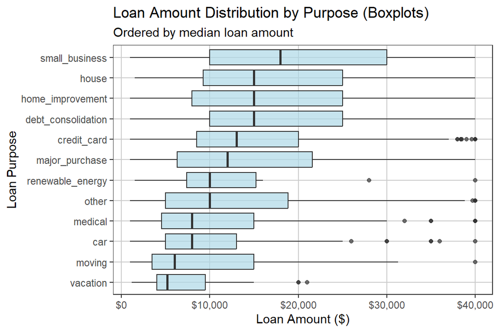

```r
#horizontal box plots for each loan category ( got the inbuilt currency scaler in library)
ggplot(loans_full_schema, aes(x = loan_amount, y = reorder(loan_purpose, loan_amount, median))) +
  geom_boxplot(fill = "lightblue", alpha = 0.7) +
  labs(
    title = "Loan Amount Distribution by Purpose (Boxplots)",
    subtitle = "Ordered by median loan amount",
    x = "Loan Amount ($)",
    y = "Loan Purpose"
  ) +
  scale_x_continuous(labels = scales::dollar_format()) +
  theme_bw() +
  theme(
    panel.grid.major = element_line(color = "grey80"),
    panel.grid.minor = element_blank()
  )
```

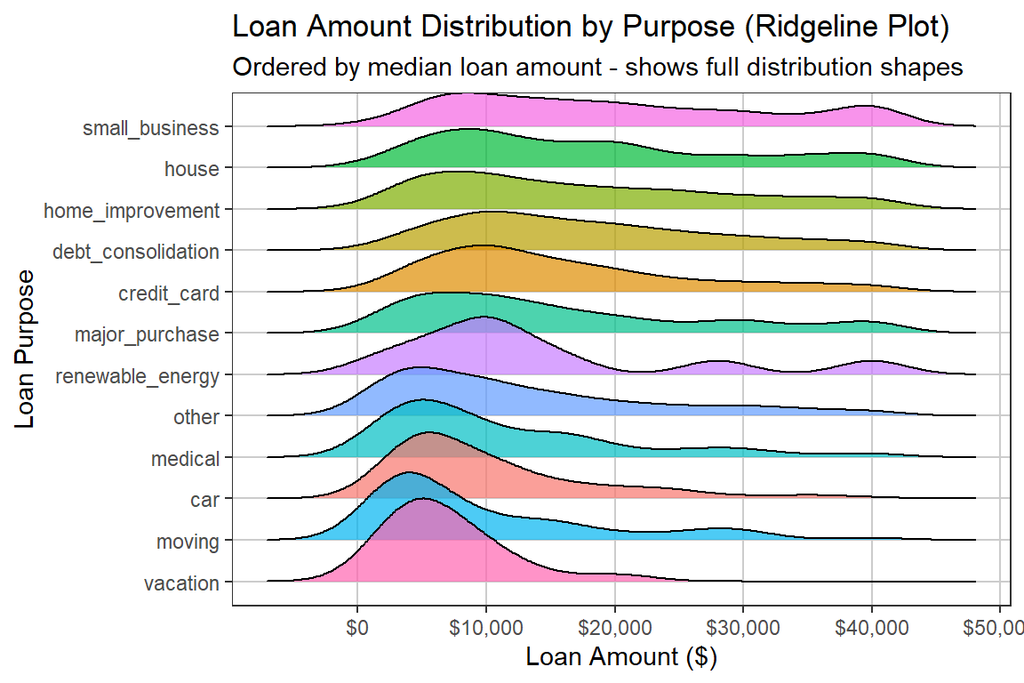

```r
library(ggridges)

## code to get the Ridgeline plot for each loan category
ggplot(loans_full_schema, aes(x = loan_amount, y = reorder(loan_purpose, loan_amount, median),
                             fill = loan_purpose)) +
  geom_density_ridges(alpha = 0.7, scale = 2) +
  labs(
    title = "Loan Amount Distribution by Purpose (Ridgeline Plot)",
    subtitle = "Ordered by median loan amount - shows full distribution shapes",
    x = "Loan Amount ($)",
    y = "Loan Purpose"
  ) +
  scale_x_continuous(labels = scales::dollar_format()) +
  theme_bw() +
  theme(
    panel.grid.major = element_line(color = "grey80"),
    panel.grid.minor = element_blank(),
    legend.position = "none"
  )
```

Boxplots provide a good comparison of medians, quartiles, and outlier values for different loan purposes, making it easy to rank purposes by typical loan size and mark extreme values.

Ridgeline plots reveal each purpose’s full distribution shape—its skewness, tail length, and any multiple peaks, giving better insight into how loan amounts truly differ by purpose.

### 6. House properties

[5 points]

Data: *ames* in the **openintro** package

1. Create a frequency bar chart for the roof styles of the properties.
2. Create a frequency bar chart for the variable representing the month in which the property was sold.
3. List all the variables that have `Ex` as a factor level.
4. Create faceted bar charts using `facet_wrap()` to display the frequency distribution of all variables identified in part c).

### 7. Pet names

[10 points]

Data: *seattlepets* in the **openintro** package

1. Create separate Cleveland dot plots for the 30 most popular dog names and 30 most popular cat names.

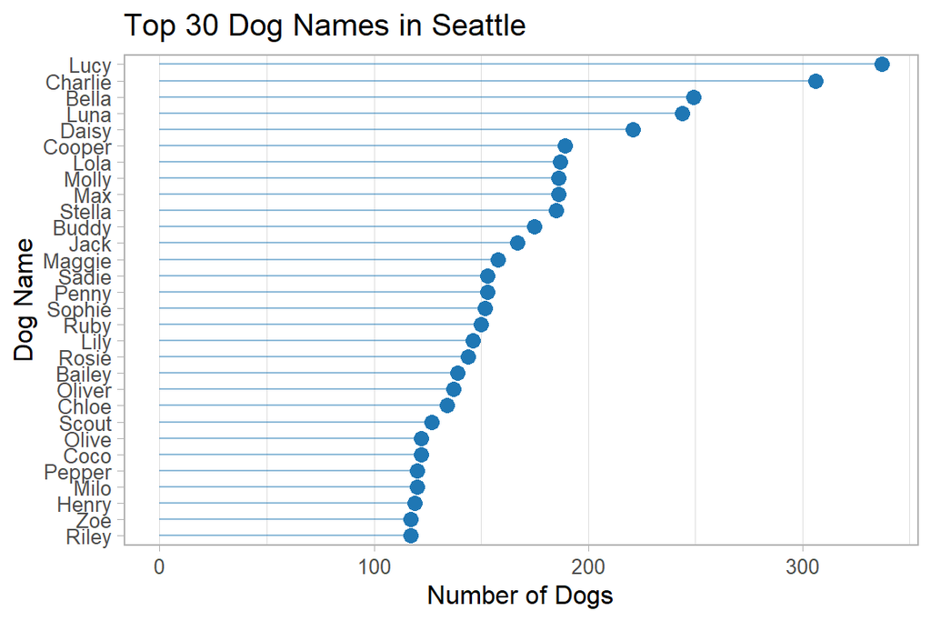

```r
library(openintro)
library(ggplot2)

data("seattlepets")
clean <- subset(seattlepets,
  !is.na(animal_name) & animal_name != "" &
  !animal_name %in% c("UNKNOWN","No Name","NO NAME")
)

# Dog plot to find 30 top dog names
dog_tab <- sort(table(clean$animal_name[clean$species=="Dog"]), TRUE)
dog_top <- head(dog_tab, 30)
ggplot(data.frame(name=names(dog_top), count=as.numeric(dog_top)),
       aes(x=count, y=reorder(name, count))) +
  geom_point(color="#1f77b4", size=3) +
  geom_segment(aes(x=0, xend=count, y=name, yend=name),
               color="#1f77b4", alpha=0.5) +
  labs(title="Top 30 Dog Names in Seattle",
       x="Number of Dogs", y="Dog Name") +
  theme_light(base_size=12) +
  theme(panel.grid.major.y=element_blank())
```

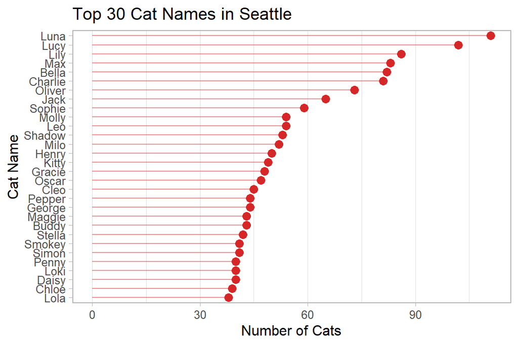

```r
# plot to find top 30 cat names

cat_tab <- sort(table(clean$animal_name[clean$species=="Cat"]), TRUE)
cat_top <- head(cat_tab, 30)
ggplot(data.frame(name=names(cat_top), count=as.numeric(cat_top)),
       aes(x=count, y=reorder(name, count))) +
  geom_point(color="#d62728", size=3) +
  geom_segment(aes(x=0, xend=count, y=name, yend=name),
               color="#d62728", alpha=0.5) +
  labs(title="Top 30 Cat Names in Seattle",
       x="Number of Cats", y="Cat Name") +
  theme_light(base_size=12) +
  theme(panel.grid.major.y=element_blank())
```

2. Find the 30 most popular names for dogs and cats combined, and create a multidot Cleveland dot plot showing the counts for dogs, cats, and total for each of these 30 names. (One color for dogs, one color for cats, one color for total.) Order the dots by the total count.

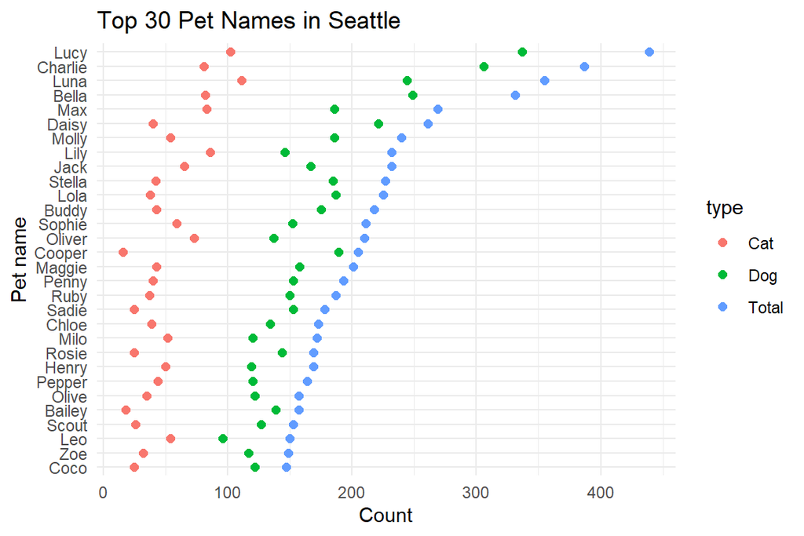

```r
# Top 30 Pet Names Combined
library(ggplot2)
library(openintro)

data("seattlepets")

pets <- seattlepets |>
  subset(!is.na(animal_name) &
           animal_name != "" &
           !(animal_name %in%
               c("UNKNOWN","Unknown","No Name","NO NAME")))
#taking counts of each specie here and merging them
dog_counts <- as.data.frame(table(
  pets$animal_name[pets$species == "Dog"]))
names(dog_counts) <- c("name", "dog_count")

cat_counts <- as.data.frame(table(
  pets$animal_name[pets$species == "Cat"]))
names(cat_counts) <- c("name", "cat_count")

all_counts <- merge(dog_counts, cat_counts,
                    by = "name", all = TRUE)
all_counts[is.na(all_counts)] <- 0
all_counts$total <- all_counts$dog_count +
                    all_counts$cat_count

#taking top 30 combined
top30 <- head(all_counts[order(-all_counts$total), ], 30)

plot_data <- data.frame(
  name  = rep(top30$name, 3),
  count = c(top30$dog_count,
            top30$cat_count,
            top30$total),
  type  = rep(c("Dog", "Cat", "Total"),
              each = nrow(top30)),
  total = rep(top30$total, 3)
)

plot_data$name <- reorder(plot_data$name, plot_data$total)

ggplot(plot_data, aes(x = count, y = name, color = type)) +
  geom_point(size = 2) +
  labs(
    title = "Top 30 Pet Names in Seattle",
    x = "Count",
    y = "Pet name"
  ) +
  theme_minimal()
```

3. Create a scatterplot of popular cat names vs. popular dog names. Clearly some names are more “dog” names and some are more “cat” names. Decide on a metric for defining what is a “dog” name, a “cat” name, and a “neutral” name and state it explicity. What is your metric?

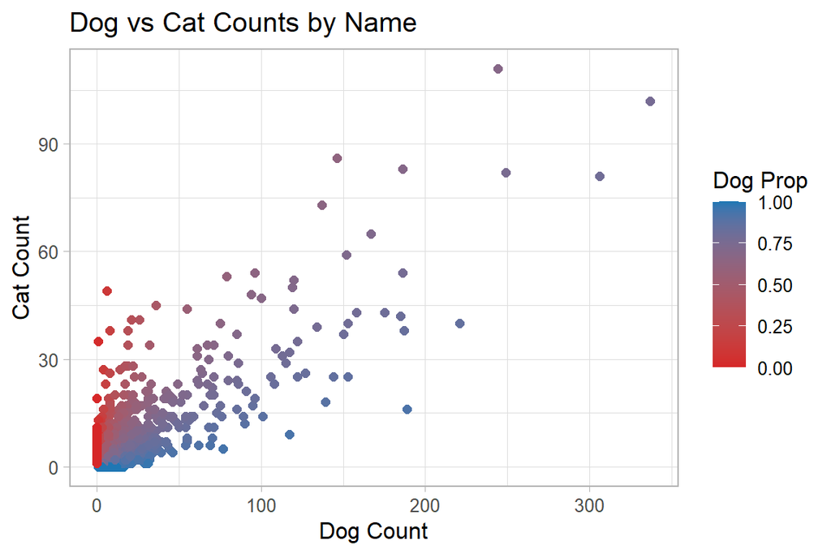

```r
# df from part b used to dog percentages
all_counts$prop_dog <- all_counts$dog_count / all_counts$total

ggplot(all_counts, aes(x=dog_count, y=cat_count)) +
  geom_point(aes(color=prop_dog), size=2) +
  scale_color_gradient(low="#d62728", high="#1f77b4", name="Dog Prop") +
  labs(title="Dog vs Cat Counts by Name",
       x="Dog Count", y="Cat Count") +
  theme_light(base_size=12)
```

4. Create a new variable for type of name (“dog”, “cat” or “neutral”) and redraw the scatterplot coloring the points by this variable. Label individual points as you see fit (don’t label all of them.)

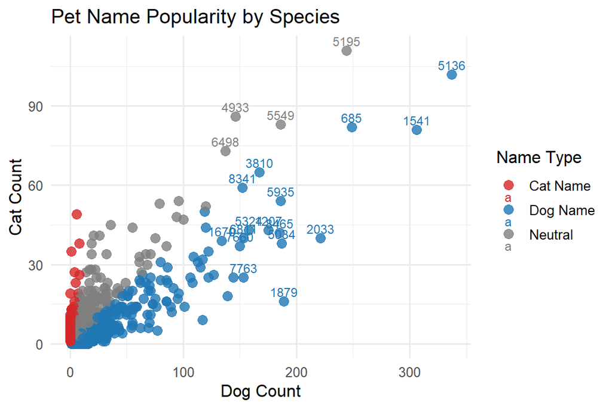

```r
#using the metrics mentioned above
all_counts$type <- with(all_counts,
  ifelse(prop_dog > 0.7, "Dog Name",
  ifelse(prop_dog < 0.3, "Cat Name","Neutral"))
)


# Label top 20 in total

top20 <- head(all_counts[order(-all_counts$total), ], 20)$name
all_counts$label <- ifelse(all_counts$name %in% top20, all_counts$name, "")

ggplot(all_counts, aes(x=dog_count, y=cat_count, color=type)) +
  geom_point(size=3, alpha=0.8) +
  geom_text(aes(label=label), vjust=-0.5, size=3) +
  scale_color_manual(values=c("Dog Name"="#1f77b4",
                              "Cat Name"="#d62728",
                              "Neutral"="#7f7f7f")) +
  labs(title="Pet Name Popularity by Species",
       x="Dog Count", y="Cat Count", color="Name Type") +
  theme_minimal(base_size=12)
```

5. What are your most interesting discoveries from this dataset?

The plots reveal that a handful of names like Bella, Luna, and Charlie—are universally popular across both dogs and cats.

Kitty, Tiger, and Cleo are almost exclusively cat names (<30% dog share).

The naming patterns suggest that dog owners tend to choose more traditional names, whereas cat owners prefer names with playfulness, reflecting their differed attitudes toward each type of pet.

### 8. House sizes and prices

[12 points]

Data: *ames* in the **openintro** package

For all, adjust parameters to the levels that provide the best views of the data.

Draw four plots of `price` vs. `area` with the following variations:

1. Scatterplot with density contour lines
2. Hexagonal heatmap of bin counts
3. Describe noteworthy patterns in the data, using the “Movie ratings” example on page 82 (last page of Section 5.3) as a guide.
4. Create scatterplots of `price` vs. `area` faceted by `Neighborhood`. Add best fitting simple linear regression lines and sort the facets by the value of the slope of these lines from low to high. (Use `lm()` to get the slopes.)
5. Is the slope higher in neighborhoods with higher mean housing prices? Present graphical evidence and interpret in the context of this data.
6. Repeat parts d) with the following adjustment: order the faceted plots by $R^2$ from the linear regression of `price` on `area` by `Neighborhood`. Are the results the same for slope and $R^2$? Explain using examples from the graphs.